# Tidy data

(This is an informal and code heavy version of the full [tidy data paper](https://vita.had.co.nz/papers/tidy-data.html). Please refer to that for more details.)

Code also used from here https://github.com/hadley/tidy-data.git. Also see [this](https://cran.r-project.org/web/packages/tidyr/vignettes/tidy-data.html)

# Importing Data

The first step is to ensure that the data has been imported correctly. This means checking the following:

- Read in the data
- Check the packaging
- Look at the top and bottom of your data
- Check n
- Validate with at least one external data source
- Make a plot

The attached dataset contains 5,960 records of bank customers who have received home equity loans, and whether they have defaulted on the loan.

```r
hmeq <- read.csv("hmeq.csv")
head(hmeq)
```

```
#>   Default Loan Mortgage  Value  Reason    Job  YOJ Derogatories Delinquencies
#> 1       1 1100    25860  39025 HomeImp  Other 10.5            0             0
#> 2       1 1300    70053  68400 HomeImp  Other  7.0            0             2
#> 3       1 1500    13500  16700 HomeImp  Other  4.0            0             0
#> 4       1 1500       NA     NA                  NA           NA            NA
#> 5       0 1700    97800 112000 HomeImp Office  3.0            0             0
#> 6       1 1700    30548  40320 HomeImp  Other  9.0            0             0
#>       CLAGE Inquiries CLNO  DEBTINC
#> 1  94.36667         1    9       NA
#> 2 121.83333         0   14       NA
#> 3 149.46667         1   10       NA
#> 4        NA        NA   NA       NA
#> 5  93.33333         0   14       NA
#> 6 101.46600         1    8 37.11361
```

```r
tail(hmeq)
```

```
#>      Default  Loan Mortgage Value  Reason   Job YOJ Derogatories Delinquencies
#> 5955       0 88900    48919 93371 DebtCon Other  15            0             1
#> 5956       0 88900    57264 90185 DebtCon Other  16            0             0
#> 5957       0 89000    54576 92937 DebtCon Other  16            0             0
#> 5958       0 89200    54045 92924 DebtCon Other  15            0             0
#> 5959       0 89800    50370 91861 DebtCon Other  14            0             0
#> 5960       0 89900    48811 88934 DebtCon Other  15            0             0
#>         CLAGE Inquiries CLNO  DEBTINC
#> 5955 205.6502         0   15 34.81826
#> 5956 221.8087         0   16 36.11235
#> 5957 208.6921         0   15 35.85997
#> 5958 212.2797         0   15 35.55659
#> 5959 213.8927         0   16 34.34088
#> 5960 219.6010         0   16 34.57152
```

```r
str(hmeq)
```

```
#> 'data.frame':    5960 obs. of  13 variables:
#>  $ Default      : int  1 1 1 1 0 1 1 1 1 1 ...
#>  $ Loan         : int  1100 1300 1500 1500 1700 1700 1800 1800 2000 2000 ...
#>  $ Mortgage     : num  25860 70053 13500 NA 97800 ...
#>  $ Value        : num  39025 68400 16700 NA 112000 ...
#>  $ Reason       : chr  "HomeImp" "HomeImp" "HomeImp" "" ...
#>  $ Job          : chr  "Other" "Other" "Other" "" ...
#>  $ YOJ          : num  10.5 7 4 NA 3 9 5 11 3 16 ...
#>  $ Derogatories : int  0 0 0 NA 0 0 3 0 0 0 ...
#>  $ Delinquencies: int  0 2 0 NA 0 0 2 0 2 0 ...
#>  $ CLAGE        : num  94.4 121.8 149.5 NA 93.3 ...
#>  $ Inquiries    : int  1 0 1 NA 0 1 1 0 1 0 ...
#>  $ CLNO         : int  9 14 10 NA 14 8 17 8 12 13 ...
#>  $ DEBTINC      : num  NA NA NA NA NA ...
```

Now, let us examine the data in slightly greater details

```r
library("esquisse")
library(dplyr)
```

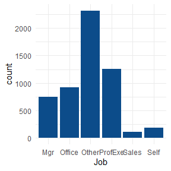

```r
library(ggplot2)
facVariables <- c("Default","Reason","Job")
hmeq$Default <- as.factor(hmeq$Default)
hmeq$Reason <- as.factor(hmeq$Reason)
hmeq$Job <- as.factor(hmeq$Job)

# Let us plot one of the categorical variables
# You can use the esquisser package to plot, and learn ggplot

# esquisser(hmeq)

hmeq %>%
 filter(!(Reason %in% "")) %>%
 filter(!(Job %in% "")) %>%
 ggplot() +
 aes(x = Job) +
 geom_bar(fill = "#0c4c8a") +
 theme_minimal()
```

```r
summary(hmeq$Job)
```

```
#>             Mgr  Office   Other ProfExe   Sales    Self
#>     279     767     948    2388    1276     109     193
```

Other than missing values, Job looks fine. Let us now look at “Reason”

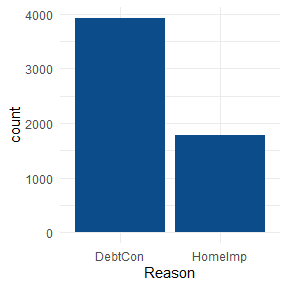

```r
hmeq %>%
 filter(!(Reason %in% "")) %>%
 ggplot() +
 aes(x = Reason) +
 geom_bar(fill = "#0c4c8a") +
 theme_minimal()
```

```r
summary(hmeq$Reason)
```

```
#>         DebtCon HomeImp
#>     252    3928    1780
```

Let us now look at some quantitative variables

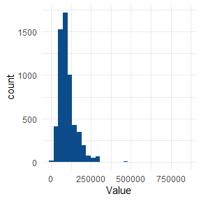

```r
hmeq %>%
 ggplot() +
 aes(x = Value) +
 geom_histogram(bins = 30L, fill = "#0c4c8a") +
 theme_minimal()
```

```r
summary(hmeq$Value)
```

```
#>    Min. 1st Qu.  Median    Mean 3rd Qu.    Max.    NA's
#>    8000   66076   89236  101776  119824  855909     112
```

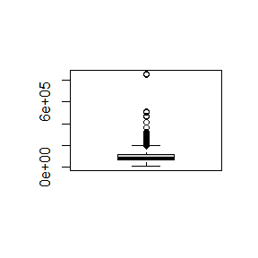

```r
boxplot(hmeq$Value, coef = 2)
```

```r
# Look for obvious inconsistencies

mortgage_negative <- hmeq$Mortgage < 0
summary(mortgage_negative)
```

```
#>    Mode   FALSE    NA's
#> logical    5442     518
```

## missing values

There are multiple approaches to filling in missing values, including omitting records with missing values

```r
# Remove all records with NA values
hmeq_removedNA <- na.omit(hmeq)
str(hmeq_removedNA)
```

```
#> 'data.frame':    3515 obs. of  13 variables:
#>  $ Default      : Factor w/ 2 levels "0","1": 2 2 1 2 1 1 1 2 2 1 ...
#>  $ Loan         : int  1700 1800 2300 2400 2400 2900 2900 2900 2900 3000 ...
#>  $ Mortgage     : num  30548 28502 102370 34863 98449 ...
#>  $ Value        : num  40320 43034 120953 47471 117195 ...
#>  $ Reason       : Factor w/ 3 levels "","DebtCon","HomeImp": 3 3 3 3 3 3 3 3 2 3 ...
#>  $ Job          : Factor w/ 7 levels "","Mgr","Office",..: 4 4 3 2 3 3 3 4 2 3 ...
#>  $ YOJ          : num  9 11 2 12 4 1 2 16 2 2 ...
#>  $ Derogatories : int  0 0 0 0 0 0 0 3 0 0 ...
#>  $ Delinquencies: int  0 0 0 0 0 0 0 0 0 0 ...
#>  $ CLAGE        : num  101.5 88.8 91 70.5 93.8 ...
#>  $ Inquiries    : int  1 0 0 1 0 0 0 2 3 0 ...
#>  $ CLNO         : int  8 8 13 21 13 13 13 8 37 14 ...
#>  $ DEBTINC      : num  37.1 36.9 31.6 38.3 29.7 ...
#>  - attr(*, "na.action")= 'omit' Named int [1:2445] 1 2 3 4 5 7 9 10 11 12 ...
#>   ..- attr(*, "names")= chr [1:2445] "1" "2" "3" "4" ...
```

```r
# Replace values by the mean
x <- hmeq$Mortgage
summary(x)
```

```
#>    Min. 1st Qu.  Median    Mean 3rd Qu.    Max.    NA's
#>    2063   46276   65019   73761   91488  399550     518
```

```r
x[is.na(x)] <- mean(x,na.rm=T)
summary(x)
```

```
#>    Min. 1st Qu.  Median    Mean 3rd Qu.    Max.
#>    2063   48139   69529   73761   88200  399550
```

```r
# We can use the Hmisc package to do imputation with other summary measures
require(Hmisc)
xmed <- hmeq$Mortgage
summary(xmed)
```

```
#>    Min. 1st Qu.  Median    Mean 3rd Qu.    Max.    NA's
#>    2063   46276   65019   73761   91488  399550     518
```

```r
xmed <- impute(xmed, fun = median)
summary(xmed)
```

```
#>
#>  518 values imputed to 65019
#>    Min. 1st Qu.  Median    Mean 3rd Qu.    Max.
#>    2063   48139   65019   73001   88200  399550
```

There are other missing value imputation methods, including multivariate imputation. Checkout the [mice](https://cran.r-project.org/web/packages/mice/mice.pdf) package.

# Data tidying

It is often said that 80% of data analysis is spent on the cleaning and preparing data. And it’s not just a first step, but it must be repeated many times over the course of analysis as new problems come to light or new data is collected. To get a handle on the problem, this paper focuses on a small, but important, aspect of data cleaning that I call data **tidying**: structuring datasets to facilitate analysis.

The principles of tidy data provide a standard way to organise data values within a dataset. A standard makes initial data cleaning easier because you don’t need to start from scratch and reinvent the wheel every time. The tidy data standard has been designed to facilitate initial exploration and analysis of the data, and to simplify the development of data analysis tools that work well together. Current tools often require translation. You have to spend time munging the output from one tool so you can input it into another. Tidy datasets and tidy tools work hand in hand to make data analysis easier, allowing you to focus on the interesting domain problem, not on the uninteresting logistics of data.

# Defining tidy data

> Happy families are all alike; every unhappy family is unhappy in its own way — Leo Tolstoy

Like families, tidy datasets are all alike but every messy dataset is messy in its own way. Tidy datasets provide a standardized way to link the structure of a dataset (its physical layout) with its semantics (its meaning). In this section, I’ll provide some standard vocabulary for describing the structure and semantics of a dataset, and then use those definitions to define tidy data.

## Data structure

```r
preg <- read.csv("preg.csv", stringsAsFactors = FALSE)
preg
```

```
#>           name treatmenta treatmentb
#> 1   John Smith         NA         18
#> 2     Jane Doe          4          1
#> 3 Mary Johnson          6          7
```

There are many ways to structure the same underlying data. The following table shows the same data as above, but the rows and columns have been transposed.

```r
t(preg)
```

```
#>            [,1]         [,2]       [,3]
#> name       "John Smith" "Jane Doe" "Mary Johnson"
#> treatmenta NA           " 4"       " 6"
#> treatmentb "18"         " 1"       " 7"
```

The data is the same, but the layout is different. Our vocabulary of rows and columns is simply not rich enough to describe why the two tables represent the same data. In addition to appearance, we need a way to describe the underlying semantics, or meaning, of the values displayed in the table.

## Data semantics

A dataset is a collection of **values**, usually either numbers (if quantitative) or strings (if qualitative). Values are organised in two ways. Every value belongs to a **variable** and an **observation**. A variable contains all values that measure the same underlying attribute (like height, temperature, duration) across units. An observation contains all values measured on the same unit (like a person, or a day, or a race) across attributes.

A tidy version of the pregnancy data looks like this:

```r
library(tidyr)
library(dplyr)
# Make tidy version

preg2 <- preg %>%
  pivot_longer(cols=c("treatmenta","treatmentb"),names_to = "treatment",values_to = "result")
preg2
```

```
#> # A tibble: 6 x 3
#>   name         treatment  result
#>   <chr>        <chr>       <int>
#> 1 John Smith   treatmenta     NA
#> 2 John Smith   treatmentb     18
#> 3 Jane Doe     treatmenta      4
#> 4 Jane Doe     treatmentb      1
#> 5 Mary Johnson treatmenta      6
#> 6 Mary Johnson treatmentb      7
```

The experimental design tells us more about the structure of the observations. In this experiment, every combination of of `name` and `treatment` was measured, a completely crossed design. The experimental design also determines whether or not missing values can be safely dropped. In this experiment, the missing value represents an observation that should have been made, but wasn’t, so it’s important to keep it. Structural missing values, which represent measurements that can’t be made (e.g., the count of pregnant males) can be safely removed.

For a given dataset, it’s usually easy to figure out what are observations and what are variables, but it is surprisingly difficult to precisely define variables and observations in general. For example, if the columns in the pregnancy data were `height` and `weight` we would have been happy to call them variables. If the columns were `height` and `width`, it would be less clear cut, as we might think of height and width as values of a `dimension` variable. If the columns were `home phone` and `work phone`, we could treat these as two variables, but in a fraud detection environment we might want variables `phone number` and `number type` because the use of one phone number for multiple people might suggest fraud. A general rule of thumb is that it is easier to describe functional relationships between variables (e.g., `z` is a linear combination of `x` and `y`, `density` is the ratio of `weight` to `volume`) than between rows, and it is easier to make comparisons between groups of observations (e.g., average of group a vs. average of group b) than between groups of columns.

In a given analysis, there may be multiple levels of observation. For example, in a trial of new allergy medication we might have three observational types: demographic data collected from each person (`age`, `sex`, `race`), medical data collected from each person on each day (`number of sneezes`, `redness of eyes`), and meteorological data collected on each day (`temperature`, `pollen count`).

Variables may change over the course of analysis. Often the variables in the raw data are very fine grained, and may add extra modelling complexity for little explanatory gain. For example, many surveys ask variations on the same question to better get at an underlying trait. In early stages of analysis, variables correspond to questions. In later stages, you change focus to traits, computed by averaging together multiple questions. This considerably simplifies analysis because you don’t need a hierarchical model, and you can often pretend that the data is continuous, not discrete.

## Tidy data

Tidy data is a standard way of mapping the meaning of a dataset to its structure. A dataset is messy or tidy depending on how rows, columns and tables are matched up with observations, variables and types. In **tidy data**:

1. Each variable forms a column.
2. Each observation forms a row.
3. Each type of observational unit forms a table.

This is Codd’s 3rd normal form, but with the constraints framed in statistical language, and the focus put on a single dataset rather than the many connected datasets common in relational databases. **Messy data** is any other arrangement of the data.

Tidy data makes it easy for an analyst or a computer to extract needed variables because it provides a standard way of structuring a dataset. Compare the different versions of the pregnancy data: in the messy version you need to use different strategies to extract different variables. This slows analysis and invites errors. If you consider how many data analysis operations involve all of the values in a variable (every aggregation function), you can see how important it is to extract these values in a simple, standard way. Tidy data is particularly well suited for vectorised programming languages like R, because the layout ensures that values of different variables from the same observation are always paired.

While the order of variables and observations does not affect analysis, a good ordering makes it easier to scan the raw values. One way of organising variables is by their role in the analysis: are values fixed by the design of the data collection, or are they measured during the course of the experiment? Fixed variables describe the experimental design and are known in advance. Computer scientists often call fixed variables dimensions, and statisticians usually denote them with subscripts on random variables. Measured variables are what we actually measure in the study. Fixed variables should come first, followed by measured variables, each ordered so that related variables are contiguous. Rows can then be ordered by the first variable, breaking ties with the second and subsequent (fixed) variables. This is the convention adopted by all tabular displays in this paper.

# Tidying messy datasets

Real datasets can, and often do, violate the three precepts of tidy data in almost every way imaginable. While occasionally you do get a dataset that you can start analysing immediately, this is the exception, not the rule. This section describes the five most common problems with messy datasets, along with their remedies:

- Column headers are values, not variable names.
- Multiple variables are stored in one column.
- Variables are stored in both rows and columns.
- Multiple types of observational units are stored in the same table.
- A single observational unit is stored in multiple tables.

Surprisingly, most messy datasets, including types of messiness not explicitly described above, can be tidied with a small set of tools: gathering, separating and spreading. The following sections illustrate each problem with a real dataset that I have encountered, and show how to tidy them.

## Column headers are values, not variable names

A common type of messy dataset is tabular data designed for presentation, where variables form both the rows and columns, and column headers are values, not variable names. While I would call this arrangement messy, in some cases it can be extremely useful. It provides efficient storage for completely crossed designs, and it can lead to extremely efficient computation if desired operations can be expressed as matrix operations.

The following code shows a subset of a typical dataset of this form. This dataset explores the relationship between income and religion in the US. It comes from a report produced by the Pew Research Center, an American think-tank that collects data on attitudes to topics ranging from religion to the internet, and produces many reports that contain datasets in this format.

```r
relig_income
```

```
#> # A tibble: 18 x 11
#>    religion `<$10k` `$10-20k` `$20-30k` `$30-40k` `$40-50k` `$50-75k` `$75-100k`
#>    <chr>      <dbl>     <dbl>     <dbl>     <dbl>     <dbl>     <dbl>      <dbl>
#>  1 Agnostic      27        34        60        81        76       137        122
#>  2 Atheist       12        27        37        52        35        70         73
#>  3 Buddhist      27        21        30        34        33        58         62
#>  4 Catholic     418       617       732       670       638      1116        949
#>  5 Don’t k~      15        14        15        11        10        35         21
#>  6 Evangel~     575       869      1064       982       881      1486        949
#>  7 Hindu          1         9         7         9        11        34         47
#>  8 Histori~     228       244       236       238       197       223        131
#>  9 Jehovah~      20        27        24        24        21        30         15
#> 10 Jewish        19        19        25        25        30        95         69
#> # ... with 8 more rows, and 3 more variables: `$100-150k` <dbl>, `>150k` <dbl>,
#> #   `Don't know/refused` <dbl>
```

This dataset has three variables, `religion`, `income` and `frequency`. To tidy it, we need to **gather** the non-variable columns into a two-column key-value pair. This action is often described as making a wide dataset long (or tall), but I’ll avoid those terms because they’re imprecise.

When gathering variables, we need to provide the name of the new key-value columns to create. The first argument, is the name of the key column, which is the name of the variable defined by the values of the column headings. In this case, it’s `income`. The second argument is the name of the value column, `frequency`. The third argument defines the columns to gather, here, every column except religion.

```r
relig_income %>%
  pivot_longer(-religion, names_to = "income", values_to = "frequency")
```

```
#> # A tibble: 180 x 3
#>    religion income             frequency
#>    <chr>    <chr>                  <dbl>
#>  1 Agnostic <$10k                     27
#>  2 Agnostic $10-20k                   34
#>  3 Agnostic $20-30k                   60
#>  4 Agnostic $30-40k                   81
#>  5 Agnostic $40-50k                   76
#>  6 Agnostic $50-75k                  137
#>  7 Agnostic $75-100k                 122
#>  8 Agnostic $100-150k                109
#>  9 Agnostic >150k                     84
#> 10 Agnostic Don't know/refused        96
#> # ... with 170 more rows
```

This form is tidy because each column represents a variable and each row represents an observation, in this case a demographic unit corresponding to a combination of `religion` and `income`.

```r
billboard
```

```
#> # A tibble: 317 x 79
#>    artist track date.entered   wk1   wk2   wk3   wk4   wk5   wk6   wk7   wk8
#>    <chr>  <chr> <date>       <dbl> <dbl> <dbl> <dbl> <dbl> <dbl> <dbl> <dbl>
#>  1 2 Pac  Baby~ 2000-02-26      87    82    72    77    87    94    99    NA
#>  2 2Ge+h~ The ~ 2000-09-02      91    87    92    NA    NA    NA    NA    NA
#>  3 3 Doo~ Kryp~ 2000-04-08      81    70    68    67    66    57    54    53
#>  4 3 Doo~ Loser 2000-10-21      76    76    72    69    67    65    55    59
#>  5 504 B~ Wobb~ 2000-04-15      57    34    25    17    17    31    36    49
#>  6 98^0   Give~ 2000-08-19      51    39    34    26    26    19     2     2
#>  7 A*Tee~ Danc~ 2000-07-08      97    97    96    95   100    NA    NA    NA
#>  8 Aaliy~ I Do~ 2000-01-29      84    62    51    41    38    35    35    38
#>  9 Aaliy~ Try ~ 2000-03-18      59    53    38    28    21    18    16    14
#> 10 Adams~ Open~ 2000-08-26      76    76    74    69    68    67    61    58
#> # ... with 307 more rows, and 68 more variables: wk9 <dbl>, wk10 <dbl>,
#> #   wk11 <dbl>, wk12 <dbl>, wk13 <dbl>, wk14 <dbl>, wk15 <dbl>, wk16 <dbl>,
#> #   wk17 <dbl>, wk18 <dbl>, wk19 <dbl>, wk20 <dbl>, wk21 <dbl>, wk22 <dbl>,
#> #   wk23 <dbl>, wk24 <dbl>, wk25 <dbl>, wk26 <dbl>, wk27 <dbl>, wk28 <dbl>,
#> #   wk29 <dbl>, wk30 <dbl>, wk31 <dbl>, wk32 <dbl>, wk33 <dbl>, wk34 <dbl>,
#> #   wk35 <dbl>, wk36 <dbl>, wk37 <dbl>, wk38 <dbl>, wk39 <dbl>, wk40 <dbl>,
#> #   wk41 <dbl>, wk42 <dbl>, wk43 <dbl>, wk44 <dbl>, wk45 <dbl>, wk46 <dbl>,
#> #   wk47 <dbl>, wk48 <dbl>, wk49 <dbl>, wk50 <dbl>, wk51 <dbl>, wk52 <dbl>,
#> #   wk53 <dbl>, wk54 <dbl>, wk55 <dbl>, wk56 <dbl>, wk57 <dbl>, wk58 <dbl>,
#> #   wk59 <dbl>, wk60 <dbl>, wk61 <dbl>, wk62 <dbl>, wk63 <dbl>, wk64 <dbl>,
#> #   wk65 <dbl>, wk66 <lgl>, wk67 <lgl>, wk68 <lgl>, wk69 <lgl>, wk70 <lgl>,
#> #   wk71 <lgl>, wk72 <lgl>, wk73 <lgl>, wk74 <lgl>, wk75 <lgl>, wk76 <lgl>
```

To tidy this dataset, we first gather together all the `wk` columns. The column names give the `week` and the values are the `rank`s:

```r
billboard2 <- billboard %>%
  pivot_longer(
    wk1:wk76,
    names_to = "week",
    values_to = "rank",
    values_drop_na = TRUE
  )
billboard2
```

```
#> # A tibble: 5,307 x 5
#>    artist  track                   date.entered week   rank
#>    <chr>   <chr>                   <date>       <chr> <dbl>
#>  1 2 Pac   Baby Don't Cry (Keep... 2000-02-26   wk1      87
#>  2 2 Pac   Baby Don't Cry (Keep... 2000-02-26   wk2      82
#>  3 2 Pac   Baby Don't Cry (Keep... 2000-02-26   wk3      72
#>  4 2 Pac   Baby Don't Cry (Keep... 2000-02-26   wk4      77
#>  5 2 Pac   Baby Don't Cry (Keep... 2000-02-26   wk5      87
#>  6 2 Pac   Baby Don't Cry (Keep... 2000-02-26   wk6      94
#>  7 2 Pac   Baby Don't Cry (Keep... 2000-02-26   wk7      99
#>  8 2Ge+her The Hardest Part Of ... 2000-09-02   wk1      91
#>  9 2Ge+her The Hardest Part Of ... 2000-09-02   wk2      87
#> 10 2Ge+her The Hardest Part Of ... 2000-09-02   wk3      92
#> # ... with 5,297 more rows
```

Here we use `na.rm` to drop any missing values from the gather columns. In this data, missing values represent weeks that the song wasn’t in the charts, so can be safely dropped.

In this case it’s also nice to do a little cleaning, converting the week variable to a number, and figuring out the date corresponding to each week on the charts:

```r
billboard3 <- billboard2 %>%
  mutate(
    week = extract_numeric(week),
    date = as.Date(date.entered) + 7 * (week - 1)) %>%
  select(-date.entered)
```

```
#> extract_numeric() is deprecated: please use readr::parse_number() instead
```

```r
billboard3
```

```
#> # A tibble: 5,307 x 5
#>    artist  track                    week  rank date
#>    <chr>   <chr>                   <dbl> <dbl> <date>
#>  1 2 Pac   Baby Don't Cry (Keep...     1    87 2000-02-26
#>  2 2 Pac   Baby Don't Cry (Keep...     2    82 2000-03-04
#>  3 2 Pac   Baby Don't Cry (Keep...     3    72 2000-03-11
#>  4 2 Pac   Baby Don't Cry (Keep...     4    77 2000-03-18
#>  5 2 Pac   Baby Don't Cry (Keep...     5    87 2000-03-25
#>  6 2 Pac   Baby Don't Cry (Keep...     6    94 2000-04-01
#>  7 2 Pac   Baby Don't Cry (Keep...     7    99 2000-04-08
#>  8 2Ge+her The Hardest Part Of ...     1    91 2000-09-02
#>  9 2Ge+her The Hardest Part Of ...     2    87 2000-09-09
#> 10 2Ge+her The Hardest Part Of ...     3    92 2000-09-16
#> # ... with 5,297 more rows
```

Finally, it’s always a good idea to sort the data. We could do it by artist, track and week:

```r
billboard3 %>% arrange(artist, track, week)
```

```
#> # A tibble: 5,307 x 5
#>    artist  track                    week  rank date
#>    <chr>   <chr>                   <dbl> <dbl> <date>
#>  1 2 Pac   Baby Don't Cry (Keep...     1    87 2000-02-26
#>  2 2 Pac   Baby Don't Cry (Keep...     2    82 2000-03-04
#>  3 2 Pac   Baby Don't Cry (Keep...     3    72 2000-03-11
#>  4 2 Pac   Baby Don't Cry (Keep...     4    77 2000-03-18
#>  5 2 Pac   Baby Don't Cry (Keep...     5    87 2000-03-25
#>  6 2 Pac   Baby Don't Cry (Keep...     6    94 2000-04-01
#>  7 2 Pac   Baby Don't Cry (Keep...     7    99 2000-04-08
#>  8 2Ge+her The Hardest Part Of ...     1    91 2000-09-02
#>  9 2Ge+her The Hardest Part Of ...     2    87 2000-09-09
#> 10 2Ge+her The Hardest Part Of ...     3    92 2000-09-16
#> # ... with 5,297 more rows
```

Or by date and rank:

```r
billboard3 %>% arrange(date, rank)
```

```
#> # A tibble: 5,307 x 5
#>    artist   track   week  rank date
#>    <chr>    <chr>  <dbl> <dbl> <date>
#>  1 Lonestar Amazed     1    81 1999-06-05
#>  2 Lonestar Amazed     2    54 1999-06-12
#>  3 Lonestar Amazed     3    44 1999-06-19
#>  4 Lonestar Amazed     4    39 1999-06-26
#>  5 Lonestar Amazed     5    38 1999-07-03
#>  6 Lonestar Amazed     6    33 1999-07-10
#>  7 Lonestar Amazed     7    29 1999-07-17
#>  8 Amber    Sexual     1    99 1999-07-17
#>  9 Lonestar Amazed     8    29 1999-07-24
#> 10 Amber    Sexual     2    99 1999-07-24
#> # ... with 5,297 more rows
```

## Multiple variables stored in one column

After gathering columns, the key column is sometimes a combination of multiple underlying variable names. This happens in the `tb` (tuberculosis) dataset, shown below. This dataset comes from the World Health Organisation, and records the counts of confirmed tuberculosis cases by `country`, `year`, and demographic group. The demographic groups are broken down by `sex` (m, f) and `age` (0-14, 15-25, 25-34, 35-44, 45-54, 55-64, unknown).

```r
library(tidyr)
library(stringr)
tb <- as_tibble(read.csv("tb.csv", na.strings="", stringsAsFactors = FALSE))
names(tb) <- str_replace(names(tb),"new_sp_","")

tb$new_sp <- NULL
names(tb)[1] <- "country"
head(tb)
```

```
#> # A tibble: 6 x 22
#>   country  year   m04  m514  m014 m1524 m2534 m3544 m4554 m5564   m65    mu
#>   <chr>   <int> <int> <int> <int> <int> <int> <int> <int> <int> <int> <int>
#> 1 AD       1989    NA    NA    NA    NA    NA    NA    NA    NA    NA    NA
#> 2 AD       1990    NA    NA    NA    NA    NA    NA    NA    NA    NA    NA
#> 3 AD       1991    NA    NA    NA    NA    NA    NA    NA    NA    NA    NA
#> 4 AD       1992    NA    NA    NA    NA    NA    NA    NA    NA    NA    NA
#> 5 AD       1993    NA    NA    NA    NA    NA    NA    NA    NA    NA    NA
#> 6 AD       1994    NA    NA    NA    NA    NA    NA    NA    NA    NA    NA
#> # ... with 10 more variables: f04 <int>, f514 <int>, f014 <int>, f1524 <int>,
#> #   f2534 <int>, f3544 <int>, f4554 <int>, f5564 <int>, f65 <int>, fu <int>
```

Use pivot_longer() to gather up the non-variable columns:

```r
tb2 <- tb %>%
  pivot_longer(
    !c(country, year),
    names_to = "demo",
    values_to = "n",
    values_drop_na = TRUE
  )
head(tb2)
```

```
#> # A tibble: 6 x 4
#>   country  year demo      n
#>   <chr>   <int> <chr> <int>
#> 1 AD       1996 m014      0
#> 2 AD       1996 m1524     0
#> 3 AD       1996 m2534     0
#> 4 AD       1996 m3544     4
#> 5 AD       1996 m4554     1
#> 6 AD       1996 m5564     0
```

Split into gender and age columns

```r
tb3 <- tb2 %>%
  separate(demo, c("sex", "age"), 1)
head(tb3)
```

```
#> # A tibble: 6 x 5
#>   country  year sex   age       n
#>   <chr>   <int> <chr> <chr> <int>
#> 1 AD       1996 m     014       0
#> 2 AD       1996 m     1524      0
#> 3 AD       1996 m     2534      0
#> 4 AD       1996 m     3544      4
#> 5 AD       1996 m     4554      1
#> 6 AD       1996 m     5564      0
```

Alternatively, we could have combined the above steps

```r
tb %>% pivot_longer(
  !c(country, year),
  names_to = c("sex", "age"),
  names_pattern = "(.)(.+)",
  values_to = "n",
  values_drop_na = TRUE
)
```

```
#> # A tibble: 35,750 x 5
#>    country  year sex   age       n
#>    <chr>   <int> <chr> <chr> <int>
#>  1 AD       1996 m     014       0
#>  2 AD       1996 m     1524      0
#>  3 AD       1996 m     2534      0
#>  4 AD       1996 m     3544      4
#>  5 AD       1996 m     4554      1
#>  6 AD       1996 m     5564      0
#>  7 AD       1996 m     65        0
#>  8 AD       1996 f     014       0
#>  9 AD       1996 f     1524      1
#> 10 AD       1996 f     2534      1
#> # ... with 35,740 more rows
```

Storing the values in this form resolves a problem in the original data. We want to compare rates, not counts, which means we need to know the population. In the original format, there is no easy way to add a population variable. It has to be stored in a separate table, which makes it hard to correctly match populations to counts. In tidy form, adding variables for population and rate is easy because they’re just additional columns.

## Variables are stored in both rows and columns

```r
weather <- as_tibble(read.csv("weather.csv", stringsAsFactors = FALSE))
weather
```

```
#> # A tibble: 22 x 36
#>        X id     year month element    d1    d2    d3    d4    d5    d6    d7
#>    <int> <chr> <int> <int> <chr>   <dbl> <dbl> <dbl> <dbl> <dbl> <dbl> <dbl>
#>  1     1 MX17~  2010     1 tmax       NA  NA    NA      NA  NA      NA    NA
#>  2     2 MX17~  2010     1 tmin       NA  NA    NA      NA  NA      NA    NA
#>  3     3 MX17~  2010     2 tmax       NA  27.3  24.1    NA  NA      NA    NA
#>  4     4 MX17~  2010     2 tmin       NA  14.4  14.4    NA  NA      NA    NA
#>  5     5 MX17~  2010     3 tmax       NA  NA    NA      NA  32.1    NA    NA
#>  6     6 MX17~  2010     3 tmin       NA  NA    NA      NA  14.2    NA    NA
#>  7     7 MX17~  2010     4 tmax       NA  NA    NA      NA  NA      NA    NA
#>  8     8 MX17~  2010     4 tmin       NA  NA    NA      NA  NA      NA    NA
#>  9     9 MX17~  2010     5 tmax       NA  NA    NA      NA  NA      NA    NA
#> 10    10 MX17~  2010     5 tmin       NA  NA    NA      NA  NA      NA    NA
#> # ... with 12 more rows, and 24 more variables: d8 <dbl>, d9 <lgl>, d10 <dbl>,
#> #   d11 <dbl>, d12 <lgl>, d13 <dbl>, d14 <dbl>, d15 <dbl>, d16 <dbl>,
#> #   d17 <dbl>, d18 <lgl>, d19 <lgl>, d20 <lgl>, d21 <lgl>, d22 <lgl>,
#> #   d23 <dbl>, d24 <lgl>, d25 <dbl>, d26 <dbl>, d27 <dbl>, d28 <dbl>,
#> #   d29 <dbl>, d30 <dbl>, d31 <dbl>
```

It has variables in individual columns (`id`, `year`, `month`), spread across columns (`day`, d1-d31) and across rows (`tmin`, `tmax`) (minimum and maximum temperature). Months with fewer than 31 days have structural missing values for the last day(s) of the month.

To tidy this dataset we first gather the day columns by using pivot_longer:

```r
weather2 <- weather %>%
  pivot_longer(
    d1:d31,
    names_to = "day",
    values_to = "value",
    values_drop_na = TRUE
  )
weather2
```

```
#> # A tibble: 66 x 7
#>        X id       year month element day   value
#>    <int> <chr>   <int> <int> <chr>   <chr> <dbl>
#>  1     1 MX17004  2010     1 tmax    d30    27.8
#>  2     2 MX17004  2010     1 tmin    d30    14.5
#>  3     3 MX17004  2010     2 tmax    d2     27.3
#>  4     3 MX17004  2010     2 tmax    d3     24.1
#>  5     3 MX17004  2010     2 tmax    d11    29.7
#>  6     3 MX17004  2010     2 tmax    d23    29.9
#>  7     4 MX17004  2010     2 tmin    d2     14.4
#>  8     4 MX17004  2010     2 tmin    d3     14.4
#>  9     4 MX17004  2010     2 tmin    d11    13.4
#> 10     4 MX17004  2010     2 tmin    d23    10.7
#> # ... with 56 more rows
```

For presentation, I’ve dropped the missing values, making them implicit rather than explicit. This is ok because we know how many days are in each month and can easily reconstruct the explicit missing values.

We’ll also do a little cleaning:

```r
weather3 <- weather2 %>%
  mutate(day = as.integer(gsub("d", "", day))) %>%
  select(id, year, month, day, element, value)
weather3
```

```
#> # A tibble: 66 x 6
#>    id       year month   day element value
#>    <chr>   <int> <int> <int> <chr>   <dbl>
#>  1 MX17004  2010     1    30 tmax     27.8
#>  2 MX17004  2010     1    30 tmin     14.5
#>  3 MX17004  2010     2     2 tmax     27.3
#>  4 MX17004  2010     2     3 tmax     24.1
#>  5 MX17004  2010     2    11 tmax     29.7
#>  6 MX17004  2010     2    23 tmax     29.9
#>  7 MX17004  2010     2     2 tmin     14.4
#>  8 MX17004  2010     2     3 tmin     14.4
#>  9 MX17004  2010     2    11 tmin     13.4
#> 10 MX17004  2010     2    23 tmin     10.7
#> # ... with 56 more rows
```

This dataset is mostly tidy, but the `element` column is not a variable; it stores the names of variables. (Not shown in this example are the other meteorological variables `prcp` (precipitation) and `snow` (snowfall)). Fixing this requires the spread operation. This performs the inverse of gathering by spreading the `element` and `value` columns back out into the columns:

```r
weather3 %>%
  pivot_wider(names_from = element, values_from = value)
```

```
#> # A tibble: 33 x 6
#>    id       year month   day  tmax  tmin
#>    <chr>   <int> <int> <int> <dbl> <dbl>
#>  1 MX17004  2010     1    30  27.8  14.5
#>  2 MX17004  2010     2     2  27.3  14.4
#>  3 MX17004  2010     2     3  24.1  14.4
#>  4 MX17004  2010     2    11  29.7  13.4
#>  5 MX17004  2010     2    23  29.9  10.7
#>  6 MX17004  2010     3     5  32.1  14.2
#>  7 MX17004  2010     3    10  34.5  16.8
#>  8 MX17004  2010     3    16  31.1  17.6
#>  9 MX17004  2010     4    27  36.3  16.7
#> 10 MX17004  2010     5    27  33.2  18.2
#> # ... with 23 more rows
```

This form is tidy: there’s one variable in each column, and each row represents one day.

## Multiple types in one table

Datasets often involve values collected at multiple levels, on different types of observational units. During tidying, each type of observational unit should be stored in its own table. This is closely related to the idea of database normalisation, where each fact is expressed in only one place. It’s important because otherwise inconsistencies can arise.

The billboard dataset actually contains observations on two types of observational units: the song and its rank in each week. This manifests itself through the duplication of facts about the song: `artist` is repeated many times.

This dataset needs to be broken down into two pieces: a song dataset which stores `artist` and `song name`, and a ranking dataset which gives the `rank` of the `song` in each `week`. We first extract a `song` dataset:

```r
song <- billboard3 %>%
 distinct(artist, track) %>%
  mutate(song_id = row_number())
song
```

```
#> # A tibble: 317 x 3
#>    artist         track                   song_id
#>    <chr>          <chr>                     <int>
#>  1 2 Pac          Baby Don't Cry (Keep...       1
#>  2 2Ge+her        The Hardest Part Of ...       2
#>  3 3 Doors Down   Kryptonite                    3
#>  4 3 Doors Down   Loser                         4
#>  5 504 Boyz       Wobble Wobble                 5
#>  6 98^0           Give Me Just One Nig...       6
#>  7 A*Teens        Dancing Queen                 7
#>  8 Aaliyah        I Don't Wanna                 8
#>  9 Aaliyah        Try Again                     9
#> 10 Adams, Yolanda Open My Heart                10
#> # ... with 307 more rows
```

Then use that to make a `rank` dataset by replacing repeated song facts with a pointer to song details (a unique song id):

```r
rank <- billboard3 %>%
  left_join(song, c("artist", "track")) %>%
  select(song_id, date, week, rank) %>%
  arrange(song_id, date)
rank
```

```
#> # A tibble: 5,307 x 4
#>    song_id date        week  rank
#>      <int> <date>     <dbl> <dbl>
#>  1       1 2000-02-26     1    87
#>  2       1 2000-03-04     2    82
#>  3       1 2000-03-11     3    72
#>  4       1 2000-03-18     4    77
#>  5       1 2000-03-25     5    87
#>  6       1 2000-04-01     6    94
#>  7       1 2000-04-08     7    99
#>  8       2 2000-09-02     1    91
#>  9       2 2000-09-09     2    87
#> 10       2 2000-09-16     3    92
#> # ... with 5,297 more rows
```

You could also imagine a `week` dataset which would record background information about the week, maybe the total number of songs sold or similar “demographic” information.

Normalisation is useful for tidying and eliminating inconsistencies. However, there are few data analysis tools that work directly with relational data, so analysis usually also requires denormalisation or the merging the datasets back into one table.

## One type in multiple tables

It’s also common to find data values about a single type of observational unit spread out over multiple tables or files. These tables and files are often split up by another variable, so that each represents a single year, person, or location. As long as the format for individual records is consistent, this is an easy problem to fix:

1. Read the files into a list of tables.
2. For each table, add a new column that records the original file name (the file name is often the value of an important variable).
3. Combine all tables into a single table.

Purrr makes this straightforward in R. The following code generates a vector of file names in a directory (`data/`) which match a regular expression (ends in `.csv`). Next we name each element of the vector with the name of the file. We do this because will preserve the names in the following step, ensuring that each row in the final data frame is labeled with its source. Finally, `map_dfr()` loops over each path, reading in the csv file and combining the results into a single data frame.

```r
library(purrr)
paths <- dir("data", pattern = "\\.csv$", full.names = TRUE)
names(paths) <- basename(paths)
map_dfr(paths, read.csv, stringsAsFactors = FALSE, .id = "filename")
```

Once you have a single table, you can perform additional tidying as needed. An example of this type of cleaning can be found at https://github.com/hadley/data-baby-names which takes 129 yearly baby name tables provided by the US Social Security Administration and combines them into a single file.

A more complicated situation occurs when the dataset structure changes over time. For example, the datasets may contain different variables, the same variables with different names, different file formats, or different conventions for missing values. This may require you to tidy each file to individually (or, if you’re lucky, in small groups) and then combine them once tidied. An example of this type of tidying is illustrated in https://github.com/hadley/data-fuel-economy, which shows the tidying of epa fuel economy data for over 50,000 cars from 1978 to 2008. The raw data is available online, but each year is stored in a separate file and there are four major formats with many minor variations, making tidying this dataset a considerable challenge.